# Managing user IDs and Passwords

Robert Krajcik

12 December, 2021

## Introduction

Creating a protected SQL database with shinymanager::create_db()), an admin mode is available to manage access to the application.

The Risk Assessment App is initially set up for one user (“admin”) with administrator authority and a default password of “qwerty”

The Starting page of the application will be:

[figure not shown]

Note: whenever the credentials database is created, the administrator will be required to create a keyring password.  
The following prompt will appear:

[figure not shown]

## First Step for the administrator

The first thing the administrator will need to do is change the **admin** default password of “qwerty” to something with at least:

- six characters
- one number
- one lowercase character
- one uppercase character

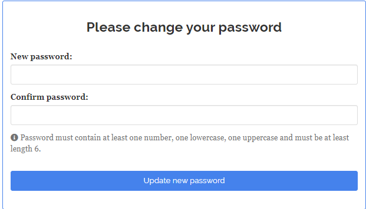

## Next Step – get into administrator mode

After successfully changing the password and logging in again, the administrator should next click on the “administrator_mode button” on the lower right corner of the dashboard screen  
This button will not be displayed for non-administrator users.

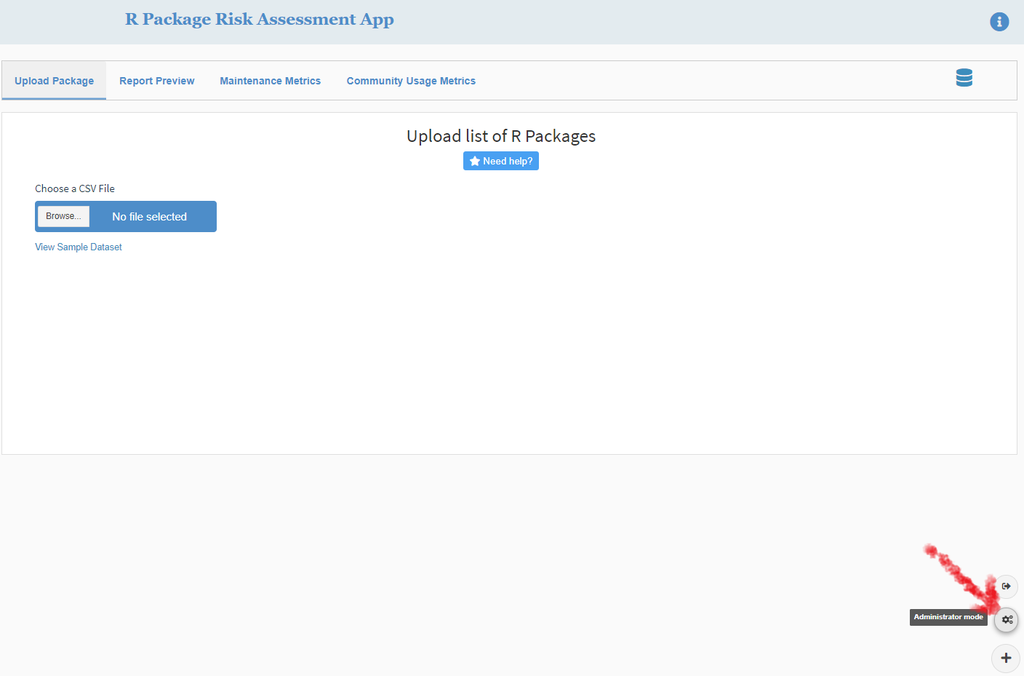

## Administrator Mode

Two tables are presented.  
The first is used to manage users, and the second to manage passwords.

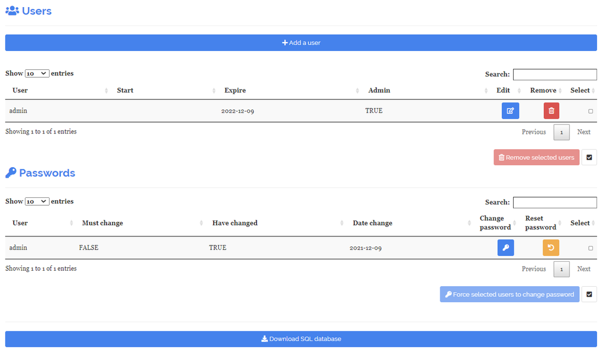

## Adding users

Now would be a good time to add users!  
At the top of the Users table, click “add user”

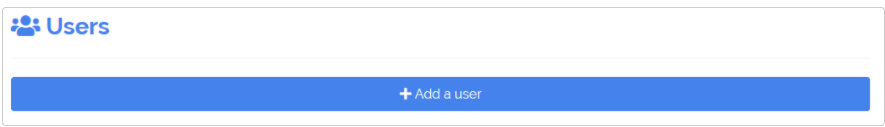

A pop-up screen will appear where you can add the user name and **optional** start and expire dates as well as a checkbox to grant administrator authority. A default password is created and (by default) the user will be required to change it the first time they log in.

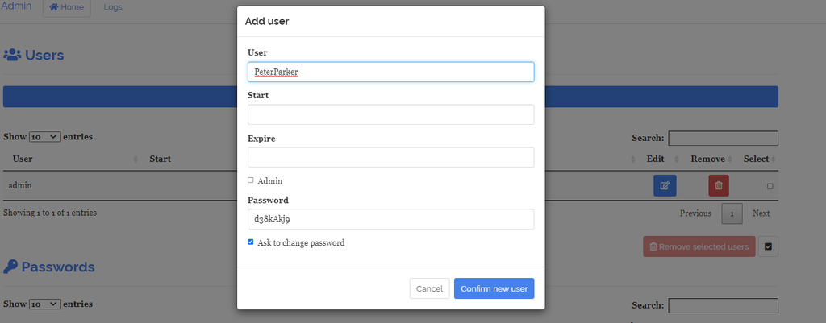

A confirmation message will appear, so you can notify the user and send them the temporary password.

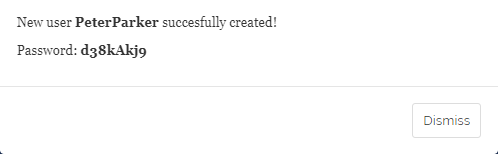

## start and expire dates

If either the **start** date is set to *after* today’s date or the **expire** date is set to *before* today’s date, an “account expired” message will appear, and the login attempt will fail.  
As administrator, you can set either or both of these dates or leave them blank for no start or expiration.

[figure not shown]

## Editing and deleting users

The first table allows editing and deleting users.

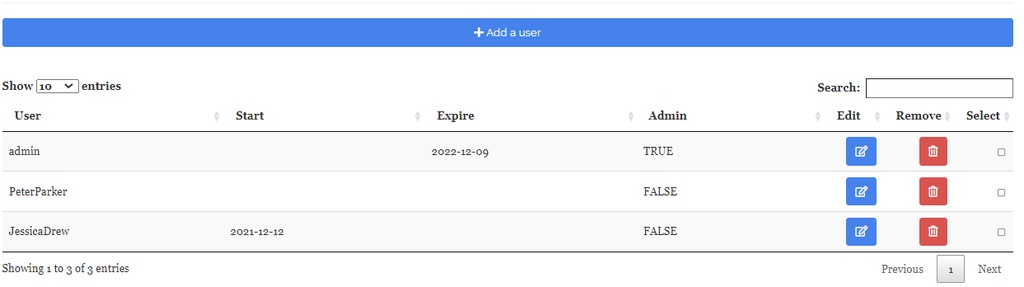

### Edit current user

Edit user information clicking on the blue *edit* button on the table.

### Delete a user

Delete a user by clicking on the red *remove* button on the table.

### Notes

- User: You cannot delete or create an existing user
- start & expire: Keep empty for no date restriction
- When adding a new user: by default, a temporary password is generated. But you can replace it with your own password and disable asking user to change it on first log-in.

## Replace yourself?

As an administrator, you can even replace your current user ID with another one.  
Note that **you cannot delete yourself**, so you will need to create another user ID first.  
This time, click “add user” and check the admin box.

The temporary password can be overridden by un-checking the “ask to change password” box.  
Maybe replace the temporary password with something you can remember.

[figure not shown]

Now sign on to this new administrator user ID and delete the original “admin” user by checking the red remove" button next to it.

## Password management

The second table allows password management:

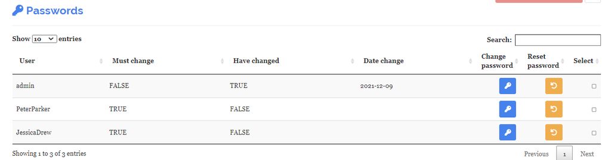

Click on the blue *Change password* button to force he user to change the password on the next log-in.

Click on the orange *Reset password* button to generate a tempoary password. Please give this to the user.

### Additional information:

- Must change: The user has to change the password next log-in.
- Have changed: The user has already changed the password.
- Date change: Date the password was updated.